# Confidence Intervals

2025

## Introduction to Confidence Intervals

- Confidence intervals (CIs) provide a range of values that is likely to contain the population parameter of interest.
- They estimate the precision of a sample statistic (e.g., the sample mean) as an estimator of a population parameter (e.g., the population mean).
- If we were to take many samples and build a confidence interval from each sample, a certain percentage (e.g., 95%) of these intervals would contain the true population parameter.

## An easy way to think of a confidence interval (two-tails)

- A confidence interval provides a range of plausible values for a population parameter (like the true mean), based on the distribution of a test statistic (e.g., the sample mean).
- In a **two-tailed** test, the CI is centered on the observed value of the test statistic, and its width depends on how much variability we estimate in that statistic based on our sample.
- In the context of a **two-tailed** test, the critical values determine how far above and below the observed statistic we go to build the interval — they define the margin of error, not fixed endpoints.

## Visualising a confidence interval

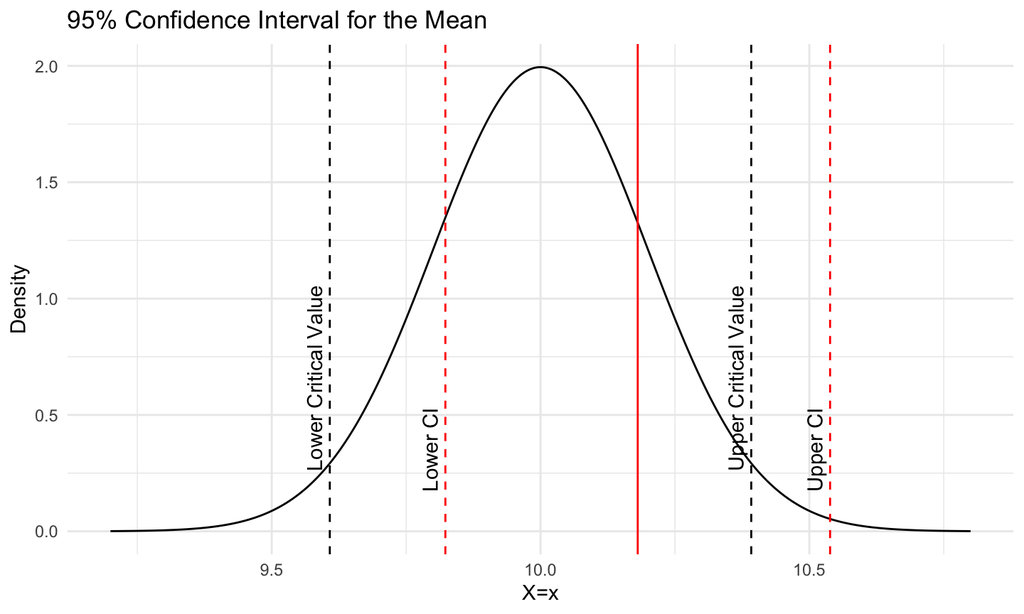

## Confidence intervals are random variables

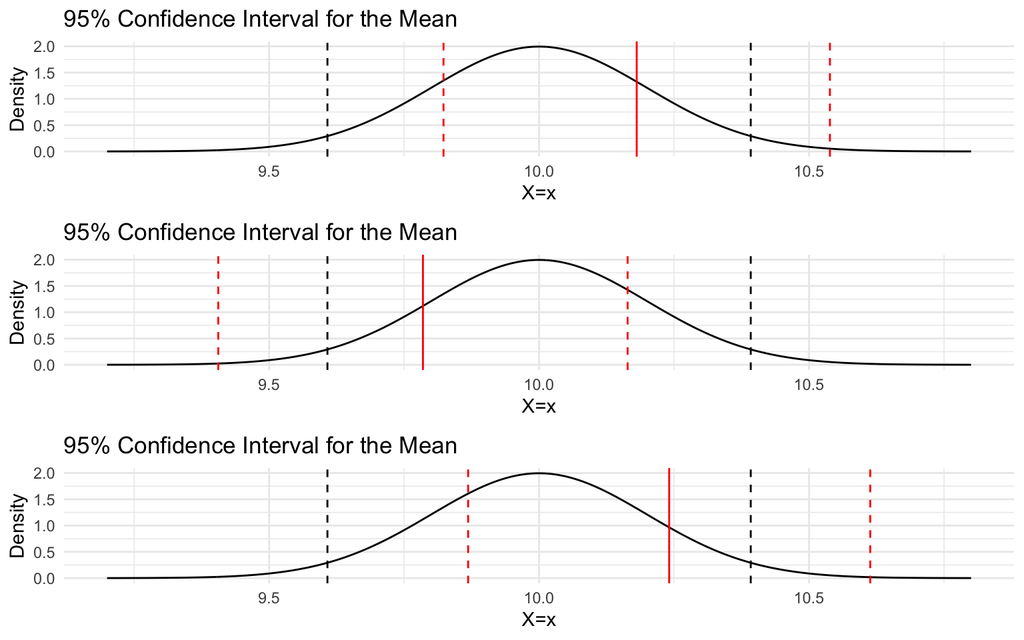

## An easy way to think of a confidence interval (one-tail)

- In a one-tailed test, the appropriate confidence interval is a one-sided interval that reflects the direction of the alternative hypothesis.
- The interval is anchored at the observed statistic and extends in only one direction — above or below — depending on whether we’re testing for an increase or a decrease.
- The entire alpha level (e.g., 5%) is placed in one tail of the sampling distribution, which shifts the cutoff and produces a longer interval in one direction.

## Comparing One-Sided vs Two-Sided Confidence Intervals

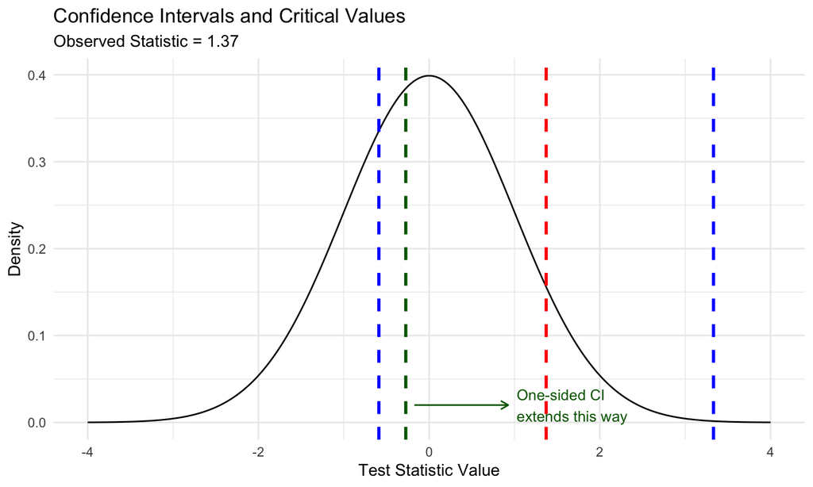

## CI interpretation

- A 95% confidence interval means that if we repeated the sampling process many times, about 95% of the intervals we construct would contain the true population parameter.
- The confidence level (e.g., 95%) refers to the method, not any one specific interval.
- Once you’ve calculated a confidence interval from your sample, the true parameter is either inside it or not — there’s no probability anymore.
- It’s a common mistake to say, “there’s a 95% chance that the true value is in this interval.”
- In frequentist statistics, parameters are fixed — only the data (and intervals) vary across repeated samples.

## How confidence intervals are formally calculated

- \[\bar{x} \pm z \times \frac{s}{\sqrt{n}}\]
- \(\bar{x}\) is the sample mean
- \(z\) is the z-score from the standard normal distribution – \(\mathscr{N}(0, 1)\) – corresponding to the desired confidence level
- \(s\) is the sample standard deviation
- \(n\) is the sample size

## Example: Calculating a 95% CI for a Mean

- Let’s calculate a 95% confidence interval for the mean of a sample with the following characteristics:
- Sample mean (\(\bar{x}\)): 100
- Sample standard deviation (\(s\)): 15
- Sample size (\(n\)): 30

## Example: Calculating a 95% CI for a Mean

```r
x_bar <- 100  # sample mean
s <- 15  # sample standard deviation
n <- 30  # sample size
z <- qnorm(0.975)  # z-score for 95% confidence

# Calculate the margin of error
margin_of_error <- z * (s / sqrt(n))

# Calculate the confidence interval
lower_bound <- x_bar - margin_of_error
upper_bound <- x_bar + margin_of_error

c(lower_bound, upper_bound)
```

```
## [1]  94.63242 105.36758
```